# Collect radial measurements from a calcified structure by interactively selecting annuli

Derek H. Ogle

2018-04-13

# 1 Introduction

The size of fish at a previous time in their life is often estimated through “back-calculation.” Back-calculation of previous lengths requires accurate measurements of annual growth on calcified structures from individual fish and a suitable model that relates growth on the structure to growth of the fish.

The [FishBC software](https://fisheries.org/bookstore/all-titles/software/70317/) is commonly used to measure lengths on a calcified structure and apply a back-calculation model to estimate length at previous ages. However, FishBC only works on out-dated computers, there are no plans to update it, and it is not open source. The functionality in the `RFishBC` package is meant to replace the FishBC software. Methods for making measurements on images of calcified structures is demonstrated in this document. Using those measurements to back-calculate fish length at a previous age is demonstrated in a separate vignette.

# 2 Vignette Assumptions

## 2.1 Understand Back-Calculation

This vignette assumes that you have a basic understanding of back-calculating fish length at previous ages. See [Vigliola and Meekan (2009)](https://www.researchgate.net/publication/226394736_The_Back-Calculation_of_Fish_Growth_From_Otoliths) and Section 11.2.3.1 in Shoup and Michaeletz (2017) for thorough introductions to this topic.

You should be aware of two foundational definitions related to measuring radii on calcified structures. First, **calcified structures** are scales, spines, fin rays, otoliths, or other bones from fish that can be processed in such a way as to show marks that represent annuli, or yearly benchmarks. Hereafter, “structure” will refer to “calcified strucure.” Second, **radii** are sequential measurements from the focus (i.e., center) of the structure to the annuli, usually along a linear transect from the focus to the margin (i.e., edge) of the structure. Radii are in contrast to increments, which are the distance between successive annuli along the transect.

## 2.2 Static Structure Images

This vignette also assumes that you can capture a static digital image of a structure. The image must be a jpeg (.jpg), portable network graphics (.png), or bitmap (.bmp) format. Images will usually be obtained from a camera mounted on a microscope and connected to a computer. Below is a sample image of a fish scale.

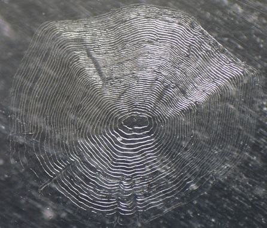

Ideally, but not necessarily, the image will also contain an object (e.g., a “scale-bar”) of known length so that actual lengths on the structure can be found. If a scale-bar is absent, then the measured lengths will be on an arbitrary scale (i.e., the actual values will be meaningless but the proportion of the total structure radius to each annulus will be meaningful). Below is a sample image of a Kiyi otolith with a 1-mm scale-bar.

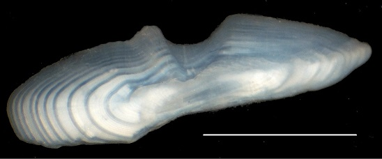

The process described herein requires that all images to be processed be stored in the same directory or folder. To be most efficient (and simple), this directory should contain ONLY image files related to a particular project (e.g., one species for one water body for one year) and all image files should be of the same type (e.g., png or jpg).

Generally, the user will “set” the current working directory in R to the directory where these images are stored with `setwd()`. If using RStudio, the working directory can be set with any of the options under the Session … Set Working Directory menu.[^1] The following is an example of setting a working directory in R.

```r
setwd("c:/work/aging/Kiyi2014")
```

Finally, note that the process described herein will produce one R data object files (.RData files; hereafter called “RData file”) for each set of measurements made on a structure images. These data files will be saved in the same directory that has the structure image files. I suggest keeping the RData and corresponding structure image files together at all times as the RData file serves as an archive of the data collected from each image.

## 2.3 R Packages

Finally, the methods described in this vignette require the following packages.

```r
library(RFishBC)
library(dplyr)    # for mutate(), inner_join()
library(tidyr)    # for spread()
```

# 3 Collect Radii Data from the Structure Image

The `digitizeRadii()` function is used to

1. Load an image of a structure.
2. Optionally provide a scaling for the image.
3. Interactively select annuli on the structure image.
4. Create an RData file that contains the radial measurements to selected annuli and other information about the structure and the data extraction process.

```r
digitizeRadii("Scale_1.jpg",ID="1",reading="DHO",edgeIsAnnulus=FALSE)
```

Further specifics of `digitizeRadii()` and its many arguments are described below.

## 3.1 The Basics

The first several arguments to `digitizeRadii()` are related to information about the structure.

- `fname=`: File name for the structure image. This is just a file name if the file is in the current working direcotry, however may be the fully pathed name if the image file is not in the current working directory. If this argument is not given, then a dialog box will be provided from which the file can be selected.
- `ID=`: **Required** unique identifier for the fish/structure.
- `reading=`: Optional label for the reading.[^4]
- `suffix=`: Optional additional label for the resultant RData file.
- `description=`: Optional detailed description about the structure. This will be saved in the RData file and shown in various plots and tables. For example, one may use `description="Cisco scale read once by Ogle on 22-Apr-18"` to provide more information about the structure reading.

The RData file that will be created after the annuli have been selected will have the same name as the image file[^5] but including the suffix optionally provided in `suffix=`. If nothing is given in `suffix=`, then a suffix will be created from `reading=`. For example, if the structure image file was named “Scale_1.jpg”, then the resultant RData file will be named “Scale_1_DHO.Rdata” if `reading="DHO"` or “Scale_1_TESTING.Rdata” if `reading="DHO"` and `suffix="TESTING"`.

Some fish will be captured at a time of year when growth for the current season has not commenced and, thus, the margin of the structure is considered to be an annulus. Other fish may be captured when growth has commence for the season (but not yet completed) such that the structure margin is not considered to be an annulus. If the scale margin is considered an annulus, then use `edgeIsAnnulus=TRUE`. If the scale margin is not considered an annulus, then use `edgeIsAnnulus=FALSE`. Identifying whether the structure margin is an annulus or not is critical to properly recording radial measurements. As such, there is no default value for this argument (i.e., it **MUST** be set by the user).

## 3.2 Setting the Scale on the Image

If actual lengths, rather than arbitrary (but proportional) lengths are needed,[^6] then a scaling factor must exist to convert measurements on the image to actual measurements on the structure. This scaling factor may be calculated from a scale-bar found on the image or provided by the user.

**Scale-bar On Image:** If a scale-bar of known length exists on the image, then use `scaleBar=TRUE` with the actual length of the scale bar given in `scaleBarLength=`. You will then need to select the two end points of the scale-bar on the structure image prior to selecting points that represent annuli. An appropriate scaling factor will then be computed from your selections and the radial measurements will be converted to the actual scale (see further below).

**Separately Define Scaling Factor:** In applications where a scale-bar does not exist on the image, the user can provide a value to `scalingFactor=` which will be used to multiply lengths on the structure image to derived actual lengths. One way to derive this scaling factor values is to capture an image of the structure at a speficif magnification on the microscope and then capture an image of an object of known length at that same magnification. A scaling factor may then be computed from the image with the object of known length and applied to the structure image. This scaling factor can be found by giving `findScalingFactor()` the file name with the object of known length and that known length in `knownLength=`. The value returned from `findScalingFactor()` can then be given to `scalingFactor=` in `digitizeRadii()`.[^7]

If no `scalingFactor=` is given or derived from a scale-bar, then the radial measurements returned by `digitizeRadii()` are simply proportional to the unknown actual lengths on the structure.

## 3.3 Selecting Annuli on the Image

The user will then be asked to select points on the structure image that represent annuli. However, **the point that represents the focus must be selected first, followed by the structure margin/edge**.[^8] If `addTransect=TRUE` (the default behavior), then a line will be drawn between these two points to aid marking the annuli. When the last point has been selected, the user must press the ESCape key in Windows or with Mac OS X (or, in Windows, select STOP in the menu on the structure image window).